# Distilling a Qwen3-32B teacher into Qwen3-14B on τ-bench retail

**One experiment, all numbers recomputed from the files in this repo** (`results/distill/*.json`, `dataset/distill/**`).

1. A **Qwen3-32B-AWQ teacher** plays the 114 hard retail *train* tasks (the ones the 14B solves rarely or never, plus mixed ones); only its **passing** conversations are kept (180 conversations).
2. The 14B (QLoRA r=16, lr 5e-5, 1 epoch = 384 steps) is fine-tuned on those conversations, loss on assistant turns only.
3. Both the new model and the **starting adapter (control, re-run on the same pod)** are tested on the 115-task retail test split, **4 trials per task**, temperature 0.7, GPT-4o as the simulated customer.

**Honest summary of the result:** the new model scores +3.9 points pass^1 over the same-pod control (45.7% vs 41.7%), which is *not* statistically significant (paired permutation p = 0.15). Against the earlier baseline measurement (37.8%, other pod, 2 trials) the gap looks nominally significant (+8.7 points on the matched first two trials, p = 0.03), but the identical starting adapter re-run on the new pod scored +2.2 points higher than that earlier test (not significant by itself), so part of that gap is pod-to-pod drift. All three comparisons are shown below.

```python
import json, math
from collections import Counter, defaultdict
from pathlib import Path
import numpy as np
import pandas as pd
import matplotlib.pyplot as plt
from scipy import stats

plt.rcParams.update({"figure.dpi": 110, "axes.spines.top": False, "axes.spines.right": False, "axes.grid": True,
                     "grid.alpha": 0.25, "axes.titlesize": 10, "axes.labelsize": 9, "legend.fontsize": 8, "font.size": 9})
ROOT = Path("..") if Path("../results/distill").exists() else Path(".")
FIG = ROOT / "figures"; FIG.mkdir(exist_ok=True)
def show(name):
    plt.tight_layout()
    plt.savefig(FIG / f"{name}.jpg", dpi=130, format="jpg", pil_kwargs={"quality": 90}, facecolor="white")
    plt.show()
RUN = json.load(open(ROOT / "results/distill/distill_run.json"))
TEACHER = json.load(open(ROOT / "results/distill/teacher_run.json"))
CONV = ROOT / "dataset/distill/retail_eval_conversations"
COMBO = {t["task_index"] for t in json.load(open(ROOT / "dataset/distill/combo_tasks_test_64.json"))}

def load_results(name):
    rows = [json.loads(l) for l in open(CONV / name)]
    by = defaultdict(dict)
    for r in rows:
        by[r["task_index"]][r["trial"]] = 1 if r["reward"] >= 1 else 0
    return rows, {t: [v[k] for k in sorted(v)] for t, v in by.items()}

NEW_ROWS, NEW = load_results("retail_new_model_4trials_results.jsonl")
CTL_ROWS, CTL = load_results("retail_starting_adapter_rerun_4trials_results.jsonl")
_old = defaultdict(list)
for r in json.load(open(ROOT / "results/passk_run.json"))["models"][1]["rows"]:   # starting adapter, earlier test, 2 trials, other pod
    _old[r["task_index"]].append((r["trial"], 1 if r["reward"] >= 1 else 0))
EARLIER = {t: [x for _, x in sorted(v)] for t, v in _old.items()}
TASKS = sorted(NEW)
C_NEW, C_CTL, C_OLD, C_TEACH = "#1E7A5C", "#E0883B", "#2F5D8A", "#7A4E9C"
print(f"new model: {len(NEW_ROWS)} rollouts, control: {len(CTL_ROWS)} rollouts, tasks: {len(TASKS)}, combo tasks in test: {len(COMBO)}")
```

```
new model: 460 rollouts, control: 460 rollouts, tasks: 115, combo tasks in test: 64
```

```python
def passk(v, k):
    n = len(v)
    return math.comb(sum(v), k) / math.comb(n, k) if n >= k else None

def per_task(d, k):
    return {t: passk(v, k) for t, v in d.items() if passk(v, k) is not None}

def mean_se(x):
    x = list(x)
    n = len(x)
    if not n:
        return None, None
    m = sum(x) / n
    return m, (math.sqrt(sum((a - m) ** 2 for a in x) / (n - 1) / n) if n > 1 else None)

def summary(d):
    return {k: mean_se(per_task(d, k).values()) for k in (1, 2, 3, 4)}

SUM = {"new model": summary(NEW), "control (same pod)": summary(CTL), "earlier test (other pod, 2 trials)": summary(EARLIER)}
pd.DataFrame({n: {f"pass^{k}": (f"{m:.1%} +/- {se:.1%}" if m is not None else "-") for k, (m, se) in s.items()} for n, s in SUM.items()})
```

|  | new model | control (same pod) | earlier test (other pod, 2 trials) |
| --- | --- | --- | --- |
| pass^1 | 45.7% +/- 3.4% | 41.7% +/- 3.4% | 37.8% +/- 3.7% |
| pass^2 | 29.9% +/- 3.4% | 27.1% +/- 3.4% | 21.7% +/- 3.9% |
| pass^3 | 22.0% +/- 3.4% | 20.2% +/- 3.4% | - |
| pass^4 | 16.5% +/- 3.5% | 16.5% +/- 3.5% | - |

## 1. Teacher: which hard tasks did Qwen3-32B solve?

```
Qwen3-32B-AWQ: 114 tasks, 419 rollouts, 199 passed, 86 tasks solved (75%); sampling of a task stopped after 2 passes
```

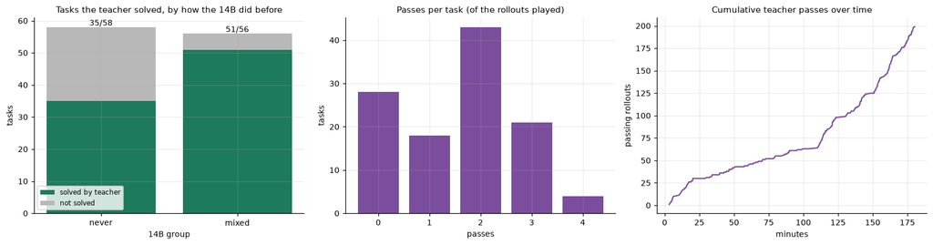

```python
S = TEACHER["summary"]
print(f"{S['model']}: {S['n_tasks']} tasks, {S['rollouts_done']} rollouts, {S['rollouts_passed']} passed, "
      f"{S['tasks_solved']} tasks solved ({S['tasks_solved']/S['n_tasks']:.0%}); sampling of a task stopped after {S['stop_after_passes']} passes")
pt = pd.DataFrame(TEACHER["per_task"])
g = pt.groupby("group_14b").agg(tasks=("task_index", "count"), solved=("solved", "sum")).reindex(["never", "mixed", "always"]).dropna()
g["unsolved"] = g["tasks"] - g["solved"]
fig, ax = plt.subplots(1, 3, figsize=(15, 4))
ax[0].bar(g.index, g["solved"], color=C_NEW, label="solved by teacher")
ax[0].bar(g.index, g["unsolved"], bottom=g["solved"], color="#B8B8B8", label="not solved")
for i, (s_, n_) in enumerate(zip(g["solved"], g["tasks"])):
    ax[0].text(i, n_ + 0.5, f"{int(s_)}/{int(n_)}", ha="center")
ax[0].set_title("Tasks the teacher solved, by how the 14B did before"); ax[0].set_xlabel("14B group"); ax[0].set_ylabel("tasks"); ax[0].legend()
cnt = pt["passes"].value_counts().sort_index()
ax[1].bar(cnt.index.astype(str), cnt.values, color=C_TEACH)
ax[1].set_title("Passes per task (of the rollouts played)"); ax[1].set_xlabel("passes"); ax[1].set_ylabel("tasks")
rows = sorted((r for r in TEACHER["_rows"] if not r.get("skipped")), key=lambda r: r["finished_at"])
t0 = rows[0]["started_run_at"]
ax[2].plot([(r["finished_at"] - t0) / 60 for r in rows], np.cumsum([1 if r["reward"] >= 1 else 0 for r in rows]), color=C_TEACH)
ax[2].set_title("Cumulative teacher passes over time"); ax[2].set_xlabel("minutes"); ax[2].set_ylabel("passing rollouts")
show("01_teacher_rollouts")
```

## 2. SFT on the 180 passing conversations

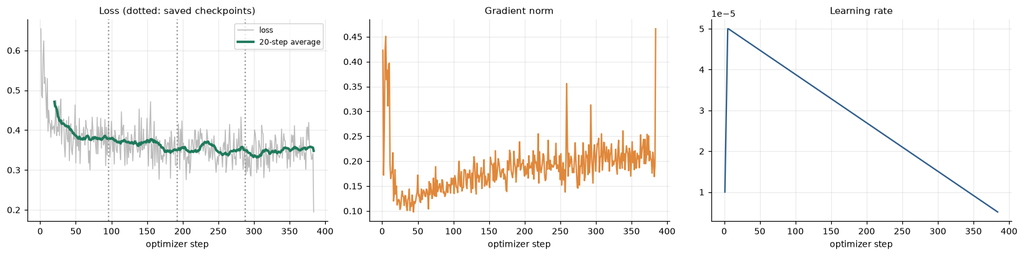

```
384 steps, 3.2 h, loss first 10 steps 0.53 -> last 10 steps 0.35
```

```python
T = RUN["training"]
step = np.array(T["step_index"])
loss = np.array(T["loss"], dtype=float)
fig, ax = plt.subplots(1, 3, figsize=(15, 3.8))
ax[0].plot(step, loss, color="#BBBBBB", lw=1, label="loss")
ax[0].plot(step[19:], np.convolve(loss, np.ones(20) / 20, mode="valid"), color=C_NEW, lw=2.5, label="20-step average")
for ck in (96, 192, 288):
    ax[0].axvline(ck, color="#999", ls=":")
ax[0].set_title("Loss (dotted: saved checkpoints)"); ax[0].legend()
ax[1].plot(step, T["grad_norm"], color=C_CTL); ax[1].set_title("Gradient norm")
ax[2].plot(step, T["lr"], color=C_OLD); ax[2].set_title("Learning rate")
for a in ax:
    a.set_xlabel("optimizer step")
show("02_sft_training")
print(f"{T['steps_total']} steps, {T['elapsed_min']/60:.1f} h, loss first 10 steps {T['loss_first10']:.2f} -> last 10 steps {T['loss_last10']:.2f}")
```

## 3. Retail test: new model vs the control

Both ran on the same pod with identical settings (vLLM 0.11.0, adapters loaded side by side). pass^k per task = C(c,k)/C(n,k) for c passes in n = 4 trials; error bars are ±1 standard error over tasks.

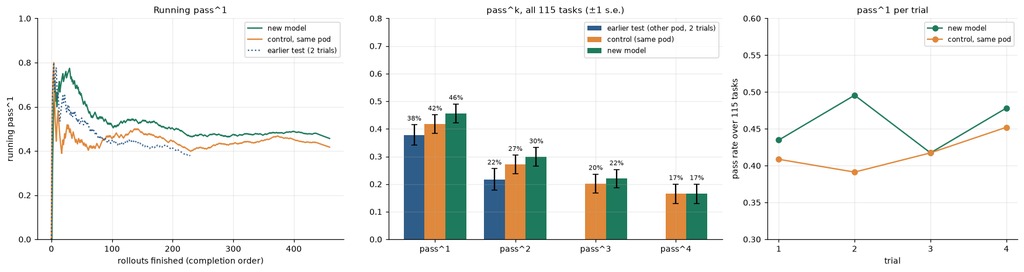

```python
def running(rows):
    rs = sorted(rows, key=lambda r: r["finished_at"])
    return np.cumsum([1 if r["reward"] >= 1 else 0 for r in rs]) / np.arange(1, len(rs) + 1)

fig, ax = plt.subplots(1, 3, figsize=(16, 4.3), gridspec_kw={"width_ratios": [1.1, 1.2, 0.9]})
ax[0].plot(running(NEW_ROWS), color=C_NEW, label="new model")
ax[0].plot(running(CTL_ROWS), color=C_CTL, label="control, same pod")
old = RUN["baseline"].get("running_pass1")
if old:
    ax[0].plot(old, color=C_OLD, ls=":", label="earlier test (2 trials)")
ax[0].set_ylim(0, 1); ax[0].set_xlabel("rollouts finished (completion order)"); ax[0].set_ylabel("running pass^1")
ax[0].set_title("Running pass^1"); ax[0].legend()

names = (("earlier test (other pod, 2 trials)", C_OLD), ("control (same pod)", C_CTL), ("new model", C_NEW))
w = 0.26
for j, (name, color) in enumerate(names):
    s = SUM[name]
    ks = [k for k in (1, 2, 3, 4) if s[k][0] is not None]
    xs = np.array(ks) - 1 + (j - 1) * w
    ax[1].bar(xs, [s[k][0] for k in ks], w, yerr=[s[k][1] for k in ks], capsize=3, color=color, label=name)
    for x, k in zip(xs, ks):
        ax[1].text(x, s[k][0] + (s[k][1] or 0) + 0.015, f"{s[k][0]:.0%}", ha="center", fontsize=7)
ax[1].set_xticks(range(4)); ax[1].set_xticklabels([f"pass^{k}" for k in (1, 2, 3, 4)]); ax[1].set_ylim(0, 0.8)
ax[1].set_title("pass^k, all 115 tasks (±1 s.e.)"); ax[1].legend(loc="upper right")

for name, color, rows in (("new model", C_NEW, NEW_ROWS), ("control, same pod", C_CTL, CTL_ROWS)):
    tr = defaultdict(list)
    for r in rows:
        tr[r["trial"]].append(1 if r["reward"] >= 1 else 0)
    ax[2].plot([k + 1 for k in sorted(tr)], [sum(tr[k]) / len(tr[k]) for k in sorted(tr)], "o-", color=color, label=name)
ax[2].set_xticks([1, 2, 3, 4]); ax[2].set_ylim(0.3, 0.6); ax[2].set_xlabel("trial"); ax[2].set_ylabel("pass rate over 115 tasks")
ax[2].set_title("pass^1 per trial"); ax[2].legend()
show("03_retail_test_overview")
```

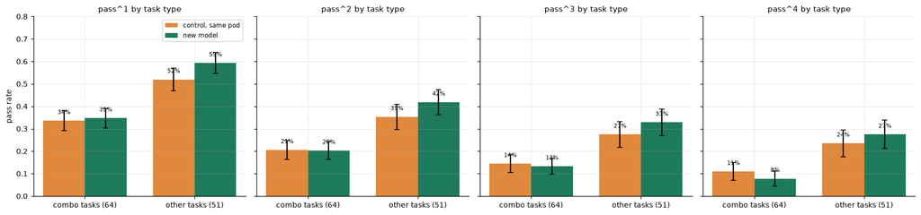

```python
fig, ax = plt.subplots(1, 4, figsize=(16, 3.8), sharey=True)
labels = [f"combo tasks ({len(COMBO)})", f"other tasks ({len(TASKS) - len(COMBO)})"]
for ci, k in enumerate((1, 2, 3, 4)):
    for j, (name, color, d) in enumerate((("control, same pod", C_CTL, CTL), ("new model", C_NEW, NEW))):
        ms, es = [], []
        for keep in (lambda t: t in COMBO, lambda t: t not in COMBO):
            m, se = mean_se(per_task({t: x for t, x in d.items() if keep(t)}, k).values())
            ms.append(m); es.append(se)
        xs = np.arange(2) + (j - 0.5) * 0.38
        ax[ci].bar(xs, ms, 0.38, yerr=es, capsize=3, color=color, label=name)
        for x, m in zip(xs, ms):
            ax[ci].text(x, m + 0.03, f"{m:.0%}", ha="center", fontsize=7)
    ax[ci].set_xticks(range(2)); ax[ci].set_xticklabels(labels); ax[ci].set_ylim(0, 0.8); ax[ci].set_title(f"pass^{k} by task type")
ax[0].legend(); ax[0].set_ylabel("pass rate")
show("04_by_task_type")
```

## 4. Is the difference real? Paired by task

```python
rng = np.random.default_rng(0)
def paired(a, b, k=1):
    xs = np.array([np.mean(a[t]) - np.mean(b[t]) if k == 1 else passk(a[t], k) - passk(b[t], k) for t in TASKS if t in a and t in b
                   and (k == 1 or (passk(a[t], k) is not None and passk(b[t], k) is not None))])
    n = len(xs); m = xs.mean(); se = xs.std(ddof=1) / math.sqrt(n)
    boots = np.array([rng.choice(xs, n).mean() for _ in range(20000)])
    flips = np.array([(xs * rng.choice([-1, 1], n)).mean() for _ in range(20000)])
    p = float((np.abs(flips) >= abs(m)).mean())
    return dict(n=n, mean=m, se=se, lo=float(np.percentile(boots, 2.5)), hi=float(np.percentile(boots, 97.5)), p=p, xs=xs, boots=boots)

first2 = lambda d: {t: v[:2] for t, v in d.items()}
vs_ctl = paired(NEW, CTL, 1)
vs_old = paired(first2(NEW), EARLIER, 1)      # matched trial counts: new model's first 2 trials vs the earlier 2-trial test
vs_rerun = paired(first2(CTL), EARLIER, 1)
vs_ctl2 = paired(NEW, CTL, 2)
tbl = pd.DataFrame([
    ["new model vs control (same pod), pass^1, 4 trials", vs_ctl], ["new model vs control (same pod), pass^2", vs_ctl2],
    ["new model (first 2 trials) vs EARLIER test, pass^1", vs_old], ["CONTROL (first 2 trials) vs EARLIER test, pass^1", vs_rerun]],
    columns=["comparison", "r"])
for c in ("mean", "se", "lo", "hi", "p"):
    tbl[c] = tbl["r"].map(lambda r: r[c])
tbl["tasks"] = tbl["r"].map(lambda r: r["n"])
tbl.drop(columns="r").style.format({"mean": "{:+.3f}", "se": "{:.3f}", "lo": "{:+.3f}", "hi": "{:+.3f}", "p": "{:.3f}"}).hide(axis="index")
```

| comparison | mean | se | lo | hi | p | tasks |
| --- | --- | --- | --- | --- | --- | --- |
| new model vs control (same pod), pass^1, 4 trials | +0.039 | 0.026 | -0.011 | +0.089 | 0.145 | 115 |
| new model vs control (same pod), pass^2 | +0.028 | 0.029 | -0.028 | +0.084 | 0.341 | 115 |
| new model (first 2 trials) vs EARLIER test, pass^1 | +0.087 | 0.038 | +0.013 | +0.161 | 0.034 | 115 |
| CONTROL (first 2 trials) vs EARLIER test, pass^1 | +0.022 | 0.038 | -0.052 | +0.096 | 0.647 | 115 |

```
pass^2 sign test: new higher on 31 tasks, control higher on 23, 61 ties, p = 0.34
```

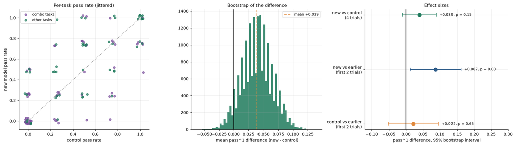

```python
pa, pb = per_task(NEW, 2), per_task(CTL, 2)
wins = sum(pa[t] > pb[t] for t in TASKS); losses = sum(pa[t] < pb[t] for t in TASKS)
sign_p = stats.binomtest(wins, wins + losses, 0.5).pvalue
print(f"pass^2 sign test: new higher on {wins} tasks, control higher on {losses}, {len(TASKS)-wins-losses} ties, p = {sign_p:.2f}")

fig, ax = plt.subplots(1, 3, figsize=(16, 4.6), gridspec_kw={"width_ratios": [1, 1, 1.1]})
rs = np.random.default_rng(1)
xj = np.array([np.mean(CTL[t]) for t in TASKS]) + rs.uniform(-0.03, 0.03, len(TASKS))
yj = np.array([np.mean(NEW[t]) for t in TASKS]) + rs.uniform(-0.03, 0.03, len(TASKS))
isc = np.array([t in COMBO for t in TASKS])
ax[0].scatter(xj[isc], yj[isc], s=22, color=C_TEACH, alpha=0.7, label="combo tasks")
ax[0].scatter(xj[~isc], yj[~isc], s=22, color=C_NEW, alpha=0.7, label="other tasks")
ax[0].plot([0, 1], [0, 1], color="#999", ls=":")
ax[0].set_xlabel("control pass rate"); ax[0].set_ylabel("new model pass rate"); ax[0].set_title("Per-task pass rate (jittered)"); ax[0].legend()
ax[1].hist(vs_ctl["boots"], bins=60, color=C_NEW, alpha=0.85)
ax[1].axvline(0, color="black"); ax[1].axvline(vs_ctl["mean"], color=C_CTL, ls="--", label=f"mean {vs_ctl['mean']:+.3f}")
ax[1].set_xlabel("mean pass^1 difference (new - control)"); ax[1].set_title("Bootstrap of the difference"); ax[1].legend()
labs = ["new vs control\n(4 trials)", "new vs earlier\n(first 2 trials)", "control vs earlier\n(first 2 trials)"]
for i, (lab, r, color) in enumerate(zip(labs, (vs_ctl, vs_old, vs_rerun), (C_NEW, C_OLD, C_CTL))):
    ax[2].errorbar(r["mean"], i, xerr=[[r["mean"] - r["lo"]], [r["hi"] - r["mean"]]], fmt="o", color=color, capsize=4, ms=8)
    ax[2].text(r["hi"] + 0.01, i, f"{r['mean']:+.3f}, p = {r['p']:.2f}", va="center", fontsize=8)
ax[2].axvline(0, color="black"); ax[2].set_yticks(range(3)); ax[2].set_yticklabels(labs); ax[2].invert_yaxis()
ax[2].set_xlim(-0.12, 0.30); ax[2].set_xlabel("pass^1 difference, 95% bootstrap interval"); ax[2].set_title("Effect sizes")
show("05_significance")
```

**How to read the right-hand panel.** The new model's gain over the *same-pod control* (4 trials) has an interval that includes zero. Its gain over the *earlier test* uses only the first 2 trials of each model so the trial counts match: it is larger (+8.7 points, p = 0.03), but the control re-run on the new pod already sits +2.2 points above the earlier test, so some of that is pod drift. The same-pod control is the comparison to trust. Note also that the new model's first two trials beat the control by +6.5 points, and trials 3 and 4 by only +1.3: the early lead partly regressed with more sampling.

## 5. Where does the difference come from?

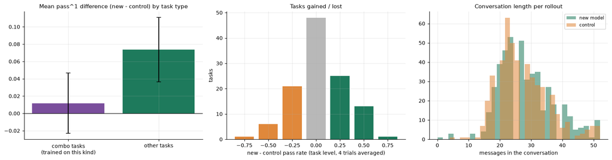

```
{'combo tasks (trained on this kind)': '+0.012 over 64 tasks', 'other tasks': '+0.074 over 51 tasks'}
```

```python
delta = {t: np.mean(NEW[t]) - np.mean(CTL[t]) for t in TASKS}
groups = {"combo tasks\n(trained on this kind)": [delta[t] for t in TASKS if t in COMBO], "other tasks": [delta[t] for t in TASKS if t not in COMBO]}
fig, ax = plt.subplots(1, 3, figsize=(15, 4))
ax[0].bar(list(groups), [np.mean(v) for v in groups.values()], yerr=[np.std(v, ddof=1) / math.sqrt(len(v)) for v in groups.values()],
          capsize=4, color=[C_TEACH, C_NEW])
ax[0].axhline(0, color="black", lw=0.8); ax[0].set_title("Mean pass^1 difference (new - control) by task type")
bins = Counter(round(v * 4) / 4 for v in delta.values())
ks = sorted(bins)
ax[1].bar(ks, [bins[k] for k in ks], width=0.2, color=[C_NEW if k > 0 else C_CTL if k < 0 else "#B8B8B8" for k in ks])
ax[1].set_xlabel("new - control pass rate (task level, 4 trials averaged)"); ax[1].set_ylabel("tasks"); ax[1].set_title("Tasks gained / lost")
for name, color, rows in (("new model", C_NEW, NEW_ROWS), ("control", C_CTL, CTL_ROWS)):
    ax[2].hist([r["n_messages"] for r in rows], bins=30, alpha=0.55, color=color, label=name)
ax[2].set_xlabel("messages in the conversation"); ax[2].set_title("Conversation length per rollout"); ax[2].legend()
show("06_where_the_gain_is")
print({k.replace(chr(10), ' '): f"{np.mean(v):+.3f} over {len(v)} tasks" for k, v in groups.items()})
```

## 6. Verdict

- The teacher solved 86 of 114 hard tasks (75%); its 180 passing conversations were the only training data.
- Against the **same-pod control** the 14B gained about **+4 points pass^1** (95% interval roughly -1 to +9, p ≈ 0.15), identical pass^4, same consistency: a plausible but unproven small effect.
- The apparent gain is concentrated in **non-combo** tasks even though training used only combo-task conversations, which hints that conversation handling transfers more than task-specific skill, but at this sample size that is a hypothesis, not a finding.
- The airline test was started and stopped after 10 rollouts: no airline comparison exists.

Raw conversations: `dataset/distill/retail_eval_conversations/`.